# R Markdown tutorial

The basics to get you started

Shai Pilosof

April 27, 2020

```r
knitr::opts_chunk$set(echo = TRUE, cache=TRUE) # global options. see more in the cheat sheet
knitr::opts_knit$set(root.dir = "/Users/Shai/GitHub/ecomplab/data_science_tutorials/R markdown/") # basic working directory
knitr:::read_chunk('/Users/Shai/GitHub/ecomplab/data_science_tutorials/R markdown/source_file.R') # A .R file from which code can be sourced.
```

# Start here

## Tutorials

1. [Rstudio’s tutorial](https://rmarkdown.rstudio.com/authoring_quick_tour.html#overview).
2. [Super-usedful for the basics](https://ourcodingclub.github.io/tutorials/rmarkdown/).
3. https://bookdown.org/yihui/rmarkdown/.
4. [Including references](https://rmarkdown.rstudio.com/authoring_bibliographies_and_citations.html).

## Cheet sheets

1. [Basic cheaty sheet](https://github.com/adam-p/markdown-here/wiki/Markdown-Cheatsheet).
2. [Official cheat sheet](https://rstudio.com/wp-content/uploads/2016/03/rmarkdown-cheatsheet-2.0.pdf).

# Basic R Markdown examples

Text can be written in bold, and italic. Lists:

- Item 1
  - Item 1.1
- Item 2
- Item 3

A references example: See Baskerville et al. (2011) and also like this: (Baskerville et al. 2011).

It is also possible to write math: $y=ae^{=\beta\cdot x}$ or between lines:

$$\Theta = \begin{pmatrix}
\alpha & \beta\\
\gamma & \delta
\end{pmatrix}$$

Possible to include tables:

```r
knitr::kable(iris[1:5, ], caption = 'A caption')
```

A caption

| Sepal.Length | Sepal.Width | Petal.Length | Petal.Width | Species |
| --- | --- | --- | --- | --- |
| 5.1 | 3.5 | 1.4 | 0.2 | setosa |
| 4.9 | 3.0 | 1.4 | 0.2 | setosa |
| 4.7 | 3.2 | 1.3 | 0.2 | setosa |
| 4.6 | 3.1 | 1.5 | 0.2 | setosa |
| 5.0 | 3.6 | 1.4 | 0.2 | setosa |

But this will not work for github_document where a markdown approach is needed:

| Tables | Are | Cool |
| --- | --- | --- |
| col 3 is | right-aligned | $1600 |
| col 2 is | centered | $12 |
| zebra stripes | are neat | $1 |

(Colons can be used to align columns.)

> A quote can be written too!

# Embedding code

# Running from a source R file.

```r
library(tidyverse)
library(bipartite)
```

Plot something by calling code from the source file:

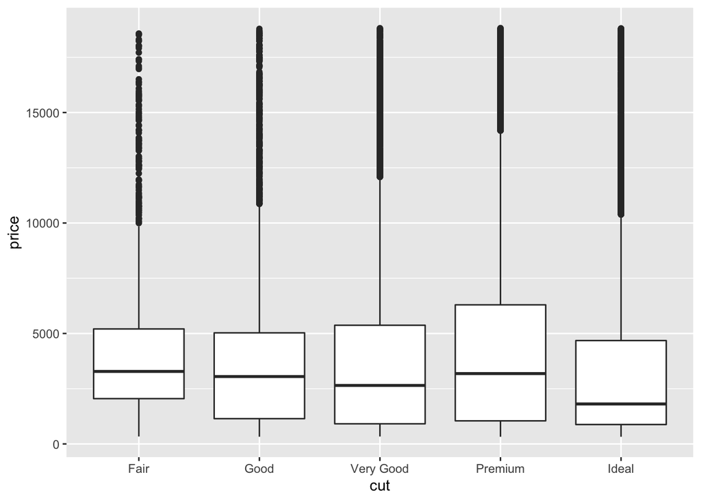

```r
ggplot(diamonds, aes(x=cut, y=price))+geom_boxplot()
```

# Caching

This is very important when you have code that takes a long time to run and you do not want to re-run it every time you kint the document. See [tutorial](https://yihui.org/knitr/options/#cache).

## Cache example

First time you knit, it will run the `modularity` chunk and put it in the cache in folder r_markdown_example_cache. Then the second time you knit it will skip the `modularity` chunk but still plot the modules because it reads it from the cache.

```r
library(bipartite)
Q_obs <- computeModules(memmott1999)
```

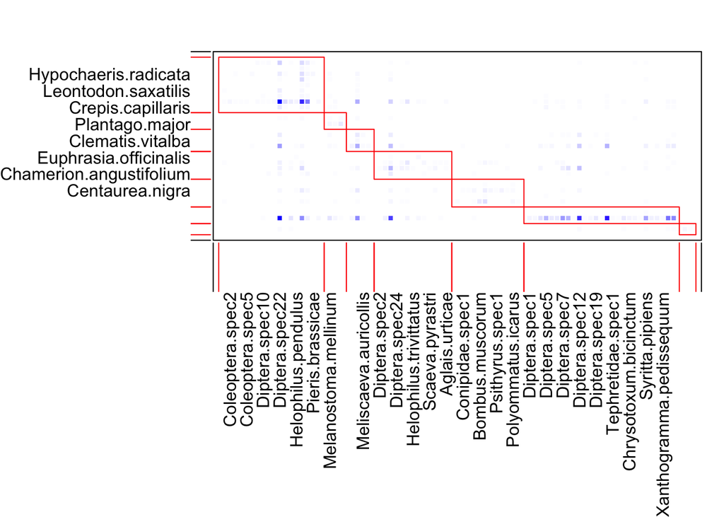

```r
plotModuleWeb(Q_obs)
```

# A real example using COVID19 data.

```r
library(tidyverse)
library(magrittr)
library(lubridate)
library(deSolve)
library(R0)

# Get data
covid19 <- read_csv('time_series_covid19_confirmed_global.csv')
covid19 %<>%
  dplyr::select(-`Province/State`, -Lat, -Long) %>%
  rename(country=`Country/Region`) %>%
  gather(key=d, value, -country) %>%
  # filter(country=='Australia', d=='2/2/20') %>% # for checking that the grouping is correct
  group_by(country, d) %>%
  summarise(cases=sum(value)) %>%
  separate(d, into=c('month','day','year')) %>%
  mutate(date=as_date(paste(year,month,day,sep='-'))) %>%
  arrange(country,date)

# Define functions
covid19_country <- function(the_country){
  x <- covid19%>%
    filter(country==the_country) %>%
    mutate(running_day=row_number())
  return(x)
}

R0_country <- function(the_country,...){
  # Estimate R0 from data
  mGT<-generation.time("gamma", c(3, 1.5))
  x <- covid19_country(the_country)
  y <- x$cases
  names(y) <- x$date
  R0 <- est.R0.EG(y, mGT,...)
  R0
}
```

# What does the data say?

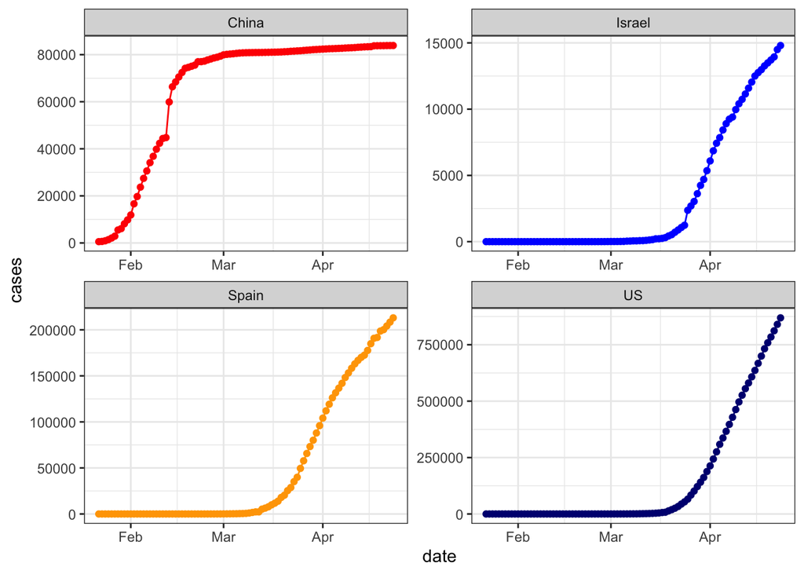

```r
# Some exploratory analysis
covid19 %>%
  filter(country=='Spain' | country=='Israel' | country=='China' | country=='US') %>%
  ggplot(aes(date, cases, color=country))+
    facet_wrap(~country, scales='free')+
    geom_point()+
    geom_line()+
    theme_bw()+
    theme(legend.position = 'none')+
    scale_color_manual(values = c('red','blue','orange', 'navy'))
```

# References

Baskerville, Edward B, Andy P Dobson, Trevor Bedford, Stefano Allesina, T Michael Anderson, and Mercedes Pascual. 2011. “Spatial Guilds in the Serengeti Food Web Revealed by a Bayesian Group Model.” *PLoS Comput. Biol.* 7 (12): e1002321. https://doi.org/10.1371/journal.pcbi.1002321.